# NFL Quarterbacks Analysis v. 2

Tom Lombardi

September 1, 2016

# Introduction

A casual observer of U.S. Football might conclude that a quarterback’s performance has little to do with mental acuity or cognitive ability. On the other hand, experienced, knowledgeable observers often cite the importance of a QB’s quick thinking and decision-making abilities.  
How much if at all does a quarterback’s cognitive ability contribute to his NFL success?

# Understanding the Problem

Every year NFL teams try to draft QBs who can perform consistently at a high-level in an incredibly competitive field of players. During the draft, teams attempt to select players based on a number of factors. For quarterbacks, one of these factors is a test of cognitive abilities, the Wonderlic Cognitive Ability Test. Therefore, scouts for NFL teams must think seriously about the role of mental abilities in a QB’s performance. Moreover, they must decide if these cognitive abilities are more important than other desirable qualities such as strength, speed and agility. The NFL Combine is a yearly series of tests performed by NFL hopefuls to provide some metrics to teams selecting new players. In order to answer our question, we will attempt to correlate QB performance in the Combine to their performance in the 2015 season.

# Understanding the Data

The NFL Combine data is available on NFLSavant. http://www.nflsavant.com/about.php The Combine data includes the following data:

- 1 - year - the year the combine test was taken: 1999-2015
- 2 - name
- 3 - firstname
- 4 - lastname
- 5 - position
- 6 - heightfeet
- 7 - heightinches
- 8 - heightinchestotal
- 9 - weight - measure in pounds
- 10 - arms
- 11 - hands
- 12 - fortyyd - forty-yard dash (seconds)
- 13 - twentyyd - twenty-yard dash (seconds)
- 14 - tenyd - ten-yard dash (seconds)
- 15 - twentyss - twenty-yard shuttle sprints (seconds)
- 16 - threecone - the three cone drill tests an athlete’s ability to change direction at high speed (seconds)
- 17 - vertical - Vertical jump tests lower-body strength (inches)
- 18 - broad - Broad jump (inches)
- 19 - bench - How many times can an athlete bench press 225 pounds?
- 20 - round - Round selected in the draft.
- 21 - college - In what college did the athlete play?
- 22 - pick - When was the athlete picked in the draft?
- 23 - pickround - In what round was the athlete selected?
- 24 - picktotal - What was the overall pick number in the draft?
- 25 - wonderlic - Score on Wonderlic Cognitive Ability Test.
- 26 - nflgrade

The 2015 Player Statistics are available from pro-footbal-reference.com. http://www.pro-football-reference.com/years/2015/passing.htm The attributes are well-documented at the source. For our purposes, we will use the following fields:

- Rate - NFL Quarterback rating
- QBR - ESPN’s Quarterback rating

We want to see how well a player’s Wonderlic score correlates with their ratings in the 2015 season.

# Data Preparation

## Load Data

Load the combine data

```r
combine <- read.csv("combine_v2.csv")
```

Load the 2015 player statistics

```r
passing <- read.csv("2015passing.csv", stringsAsFactor=FALSE)
```

## Data Cleasing

### Cleansing the passing data

The passing data are very messy. Let’s keep only the columns we need.

```r
passing <- passing[,c(1,2,4,5,22,23)]
```

Now we need to clean up the rows Remove additional metadata garbage in the data

```r
passing <- passing[passing$Rk!="Rk",]
```

Remove people who are not position QB or qb

```r
passing <- passing[passing$Pos=="QB" | passing$Pos=="qb",]
```

Now, let’s review the state of our variables.

```r
summary(passing)
```

```
##       Rk                 X                 Age
##  Length:48          Length:48          Length:48
##  Class :character   Class :character   Class :character
##  Mode  :character   Mode  :character   Mode  :character
##      Pos                Rate               QBR
##  Length:48          Length:48          Length:48
##  Class :character   Class :character   Class :character
##  Mode  :character   Mode  :character   Mode  :character
```

Most of these fields should be numeric, but our data problems forced them to be interpreted as characters. We should be seeing many number summaries. Let’s confirm this.

```r
class(passing$Age)
```

```
## [1] "character"
```

```r
typeof(passing$Age)
```

```
## [1] "character"
```

OK. Let’s recast these variables. Let’s convert the following back to numerics.

```r
passing$Age <- as.numeric(passing$Age)
passing$Rate <- as.numeric(passing$Rate)
passing$QBR <- as.numeric(passing$QBR)
```

We want the name field to be a character.

```r
passing$X <- as.character(passing$X)
```

In order to be able to match on the name fields, we’ll need to remove the additional symbols (* and +)

```r
passing$X <- gsub("[*]", "", passing$X)
passing$X <- gsub("[+]", "", passing$X)
```

Remove some more columns that we don’t need.

```r
passing$Rk <- NULL
passing$Pos <- NULL
```

### Cleansing the combine data

Pick out only the fields we need.

```r
combine <- combine[,c(1,2,5,8,9,12,13,14,15,16,17,18,23,24,25)]
```

Let’s reduce the number of rows by position (QB only)

```r
combine <- combine[combine$position=="QB",]
```

### Merging the datasets

Let’s join the data matching `combine$name` to `passing$X` We need the following library. Remember to install gdata if you have not already done so.

```r
library("gdata")
```

Merge the data where names match.

```r
qbdata <- merge(passing,combine,by.x="X",by.y="name",all.x=FALSE,all.y=FALSE)
```

We need to do some additional cleanup. Remove unneeded fields. Why are we removing these fields?

- year is not useful for our analysis.
- twentyyd has no variance; tenyd has little.
- We needed position for matching, but can’t use it for correlations.

```r
qbdata$year <- NULL
qbdata$twentyyd <- NULL
qbdata$tenyd <-NULL
qbdata$position <- NULL
```

We need to unfactor pickround

```r
qbdata$pickround <- as.numeric(levels(qbdata$pickround))[qbdata$pickround]
```

We have to handle missing values. We do not have NA values in the QBR field. If we did, we would substitute the arithmetic mean of the QBR field for the NA. We’ll reflect on this choice later. But we can just move on.

Let’s take one last look at our data.

```r
summary(qbdata)
```

```
##       X                  Age             Rate             QBR
##  Length:44          Min.   :21.00   Min.   : 65.90   Min.   :13.59
##  Class :character   1st Qu.:26.00   1st Qu.: 79.70   1st Qu.:43.01
##  Mode  :character   Median :28.00   Median : 88.45   Median :55.70
##                     Mean   :28.93   Mean   : 87.39   Mean   :53.74
##                     3rd Qu.:33.00   3rd Qu.: 93.65   3rd Qu.:63.83
##                     Max.   :38.00   Max.   :110.10   Max.   :84.88
##  heightinchestotal     weight         fortyyd         twentyss
##  Min.   :71.00     Min.   :197.0   Min.   :0.000   Min.   :0.000
##  1st Qu.:74.00     1st Qu.:214.8   1st Qu.:4.605   1st Qu.:2.925
##  Median :76.00     Median :224.5   Median :4.800   Median :4.200
##  Mean   :75.45     Mean   :224.4   Mean   :4.271   Mean   :3.195
##  3rd Qu.:77.00     3rd Qu.:232.2   3rd Qu.:4.930   3rd Qu.:4.303
##  Max.   :79.00     Max.   :248.0   Max.   :5.280   Max.   :4.660
##    threecone        vertical         broad          pickround
##  Min.   :0.000   Min.   : 0.00   Min.   :  0.00   Min.   : 0.000
##  1st Qu.:0.000   1st Qu.:26.38   1st Qu.: 74.25   1st Qu.: 1.000
##  Median :0.000   Median :30.50   Median :109.00   Median : 4.500
##  Mean   :3.041   Mean   :24.74   Mean   : 83.82   Mean   : 9.909
##  3rd Qu.:7.053   3rd Qu.:32.75   3rd Qu.:115.00   3rd Qu.:18.000
##  Max.   :7.410   Max.   :38.50   Max.   :126.00   Max.   :36.000
##    picktotal        wonderlic
##  Min.   :  0.00   Min.   : 0.00
##  1st Qu.:  1.00   1st Qu.: 0.00
##  Median : 11.00   Median :27.00
##  Mean   : 41.09   Mean   :21.82
##  3rd Qu.: 61.50   3rd Qu.:32.25
##  Max.   :250.00   Max.   :48.00
```

# Model Construction

We want to see if there is a correlation between the Wonderlic and QB ratings. Let’s use Pearson’s Product Moment Correlation Coefficient:

$\begin{aligned} r = \dfrac{\sum_{i=1}^{n}(x_{i}-\overline{x})(y_{i}-\overline{y})} {\sqrt{\sum_{i=1}^{n}(x_{i}-\overline{x})^2 \sum_{i=1}^{n}(y_{i}-\overline{y})^2}} \end{aligned}$

We can use the following command in R for this calculation.

```r
pear <- cor(qbdata[,c(3,4,7,8,9,10,11,14)], method="pearson")
pear
```

```
##                  Rate         QBR    fortyyd    twentyss   threecone
## Rate       1.00000000  0.81107728 0.24409606  0.03918038 -0.03893602
## QBR        0.81107728  1.00000000 0.32729155  0.16872657  0.01591210
## fortyyd    0.24409606  0.32729155 1.00000000  0.30159437  0.02594178
## twentyss   0.03918038  0.16872657 0.30159437  1.00000000  0.50751597
## threecone -0.03893602  0.01591210 0.02594178  0.50751597  1.00000000
## vertical  -0.10298853 -0.01841934 0.30493905  0.63966848  0.43660452
## broad     -0.07174902  0.04783468 0.29229687  0.74696476  0.50891490
## wonderlic  0.29588501  0.25000641 0.23745805 -0.07075013 -0.22415451
##              vertical       broad   wonderlic
## Rate      -0.10298853 -0.07174902  0.29588501
## QBR       -0.01841934  0.04783468  0.25000641
## fortyyd    0.30493905  0.29229687  0.23745805
## twentyss   0.63966848  0.74696476 -0.07075013
## threecone  0.43660452  0.50891490 -0.22415451
## vertical   1.00000000  0.90953481 -0.19518872
## broad      0.90953481  1.00000000 -0.17878526
## wonderlic -0.19518872 -0.17878526  1.00000000
```

In this sample, we have a weak correlation between the Wonderlic test and quarterback performance ratings. Let’s perform some additional analysis to see if it’s statistically significant.

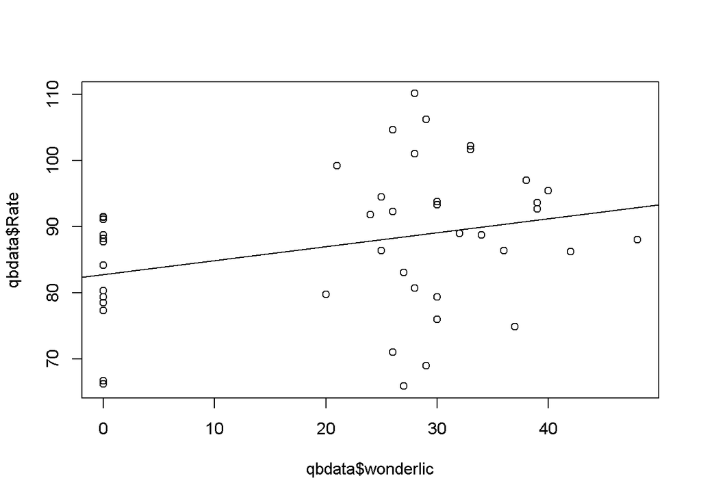

```r
plot(qbdata$wonderlic,qbdata$Rate)
abline(lm(qbdata$Rate ~ qbdata$wonderlic))
```

```r
r <- cor(qbdata$Rate, qbdata$wonderlic, method="pearson")
rsquared <- r*r
df <- nrow(qbdata)-2
sr <- sqrt((1-rsquared)/df)
t <- r/sr
cor.test(qbdata$wonderlic,qbdata$Rate, method="pearson")
```

```
##
##  Pearson's product-moment correlation
##
## data:  qbdata$wonderlic and qbdata$Rate
## t = 2.0074, df = 42, p-value = 0.05117
## alternative hypothesis: true correlation is not equal to 0
## 95 percent confidence interval:
##  -0.001091214  0.544900027
## sample estimates:
##      cor
## 0.295885
```

r is:

```r
r
```

```
## [1] 0.295885
```

degrees of freedom:

```r
df
```

```
## [1] 42
```

r-squared (coefficient of determination) is:

```r
rsquared
```

```
## [1] 0.08754794
```

The p-value is:

```r
2 * pt(-abs(t),df=df)
```

```
## [1] 0.0511656
```

We cannot reject the null hypothesis (r=0). In other words, we don’t have sufficient evidence to conclude that Rating and Wonderlic are correlated.

# Analysis

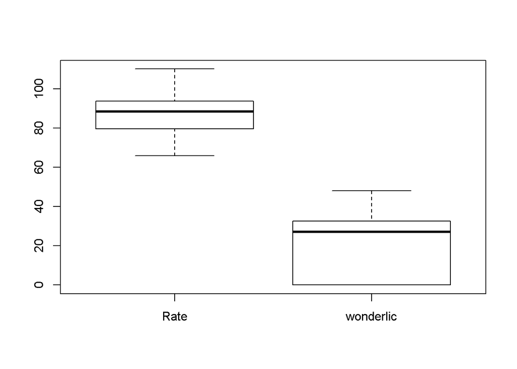

```r
boxplot(qbdata[,c(3,14)])
```

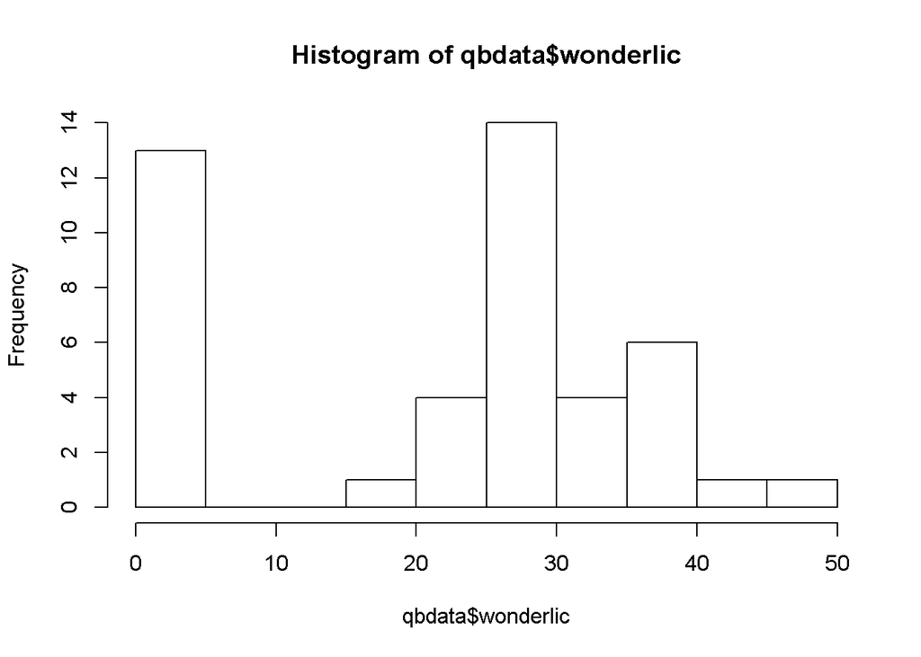

```r
hist(qbdata$wonderlic)
```

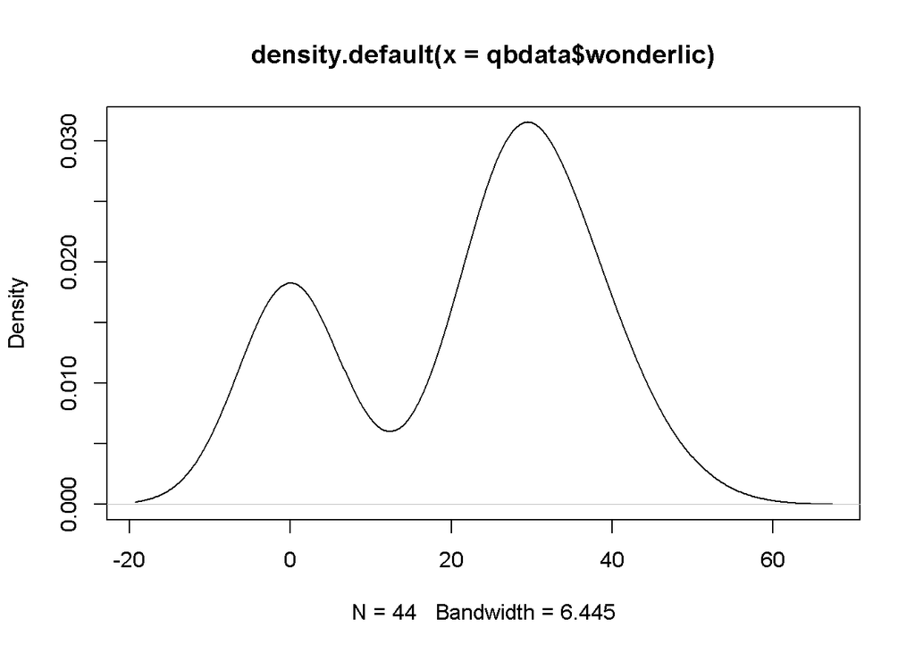

```r
plot(density(qbdata$wonderlic))
```

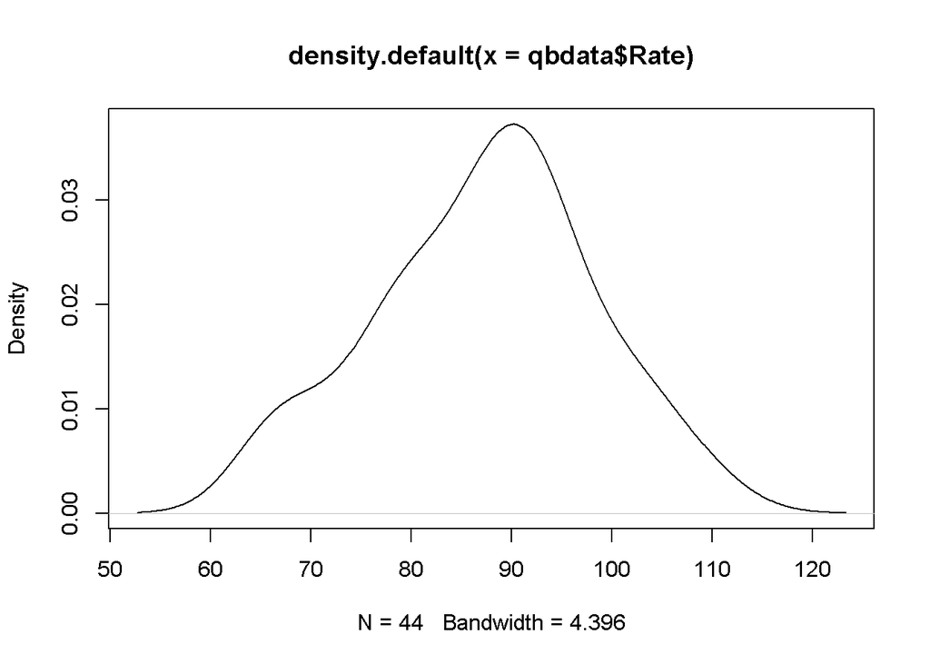

```r
plot(density(qbdata$Rate))
```

Can we repeat the analysis with Spearman’s technique?

```r
r <- cor(qbdata$Rate, qbdata$wonderlic, method="spearman")
rsquared <- r*r
df <- nrow(qbdata)-2
sr <- sqrt((1-rsquared)/df)
t <- r/sr
cor.test(qbdata$wonderlic,qbdata$Rate, method="spearman")
```

```
##
##  Spearman's rank correlation rho
##
## data:  qbdata$wonderlic and qbdata$Rate
## S = 10005, p-value = 0.05197
## alternative hypothesis: true rho is not equal to 0
## sample estimates:
##       rho
## 0.2949188
```

r is:

```r
r
```

```
## [1] 0.2949188
```

degrees of freedom:

```r
df
```

```
## [1] 42
```

r-squared is:

```r
rsquared
```

```
## [1] 0.08697709
```

The p-value is:

```r
2 * pt(-abs(t),df=df)
```

```
## [1] 0.05196539
```

We see the same weak effect with Spearman correlation. Spearman makes fewer assumptions because it is based on the rank of the data.

# Evaluation

Many others have rejected the idea that such as association exists. There are several reasons for this.

## Sample Bias

We are looking at a small set of quarterbacks and their data from a single year. We should repeat the experiment for larger data sets spanning multiple years. In fact, anecdotal evidence provides us with some excellent counter-examples to our findings. We can repeat this experiment for every year from 1999-2015.

## Alternative Hypotheses

Our data does not include players’ college performance which may be a strong predictor of QB success in the NFL. We should explore this and other alternative hypotheses.

# Reflection

Given what I know today, I would question the effectivenss of the Wonderlic as an indicator of potential success in NFL quarterbacks. A careful review of other research findings would be a reasonable next step for this data mining project.

# Resources

- http://www.bigblueview.com/2014/2/17/5408466/2014-nfl-scouting-combine-preview-new-york-giants-draft-prospects
- http://nflcombineresults.com/
- http://www.nfl.com/combine
- http://www.nfl.com/combine/workouts
- https://en.wikipedia.org/wiki/Wonderlic_test#Average_score_in_the_NFL_by_position
- Mirabile, M. (2005). Intelligence and Football: Testing for Differentials in Collegiate Quarterback Passing Performance and NFL Compensation. The Sport Journal. Web: http://thesportjournal.org/article/intelligence-and-football-testing-for-differentials-in-collegiate-quarterback-passing-performance-and-nfl-compensation/ Accessed 9/9/2015.
- http://wonderlictestsample.com/
- http://www.tandfonline.com/doi/abs/10.1080/08959280902970401#.VeZg_5PGqHs
- http://www.newyorker.com/magazine/2008/12/15/most-likely-to-succeed-2
- http://harvardsportsanalysis.org/tag/nfl-combine/
- http://harvardsportsanalysis.org/2015/02/the-combine-actually-matters-part-2/
- http://www.foxsports.com/college-football/outkick-the-coverage/do-wonderlic-scores-matter-for-quarterbacks-041515
- http://nflwonderlictestscores.com/do-wonderlic-scores-correspond-to-success-in-the-nfl/
- http://www.athleticinsight.com/Vol10Iss1/TestingSuccess.htm
- https://dialnet.unirioja.es/servlet/articulo?codigo=4672849
- http://www.theatlantic.com/entertainment/archive/2014/05/nfl-scouts-have-no-clue-how-to-predict-the-next-great-quarterback/361936/
- http://www.nytimes.com/2013/02/22/sports/football/nfl-introduces-new-way-to-test-a-players-mental-agility.html?_r=0
- http://www.newyorker.com/magazine/2008/12/15/most-likely-to-succeed-2